## Report: act_report

- Create a **250-word-minimum written report** called "act_report.pdf" or "act_report.html" that communicates the insights and displays the visualization(s) produced from your wrangled data. This is to be framed as an external document, like a blog post or magazine article, for example.

# Wrangle and Analyse Data

## Analysis and Insights from [WeRateDogs](https://twitter.com/dog_rates)

### WeRateDogs

`WeRateDogs` is a Twitter account that rates dogs. A dog owner submits a picture and details of a dog. These, together with a rating and a light-hearted comment about said dog, are posted on `WeRateDogs`.

The rating, which is out of 10, is, almost always, greater than 10 because *they're good dogs, Brent*.

`WeRateDogs` has over 9.3 million followers at the time of writing. These followers have an opinion about a dog; `likes` and `retweets` are how they express said opinion. The count of a tweet’s re-tweet and favourite ('like', if you like) will be of interest.

> Doug, our CEO, wishes everyone a splendid long weekend full of love and good snacks 🐾 [pic.twitter.com/8AwblDuP7g](https://t.co/8AwblDuP7g)

> — WeRateDogs® (@dog_rates) [September 2, 2022](https://twitter.com/dog_rates/status/1565849355185053696?ref_src=twsrc%5Etfw)

There are 3 sources of data for this project:

- Twitter archive file. This file has been downloaded by `WeRateDogs` from their Twitter archive. This archive contains basic tweet data (tweet ID, timestamp, text, etc.) for all 5000+ of their tweets as at 01 August, 2017. The file is in `csv` format
- Image prediction file. This file contains predictions from a classifier. the classifier predicts the breed of dog in each tweet. The file is in `tsv` format and is downloaded programmatically using the URL that is provided
- Twitter API. The idea is to query said API, using tweet IDs from the first data set, to acquire data that might be useful. The API returns a `JSON`-type object that will be stored in a `txt` file

### Analysis

Questions that guide the analysis:

- What is the average rating of a dog?
- Does a dog's `rating` affect the number of `favourites` it receives?
- Does a dog's `rating` affect its re-tweet count?
- What type of dog is popular?
- What is the correlation between the rating of a dog, its retweets and favourites?

#### Average rating of a dog

- average rating of a dog is *c.* 1.18, that is to say, 11.8 out of 10
- the lowest rating is 0.1
- the highest rating is 16.5
- the CV is c. 0.67 (i.e. 0.788049/1.182598). This suggests that majority of the ratings are close to the mean
- the median is less than the mean; this suggests a skew to the right

the histogram illustrates this...

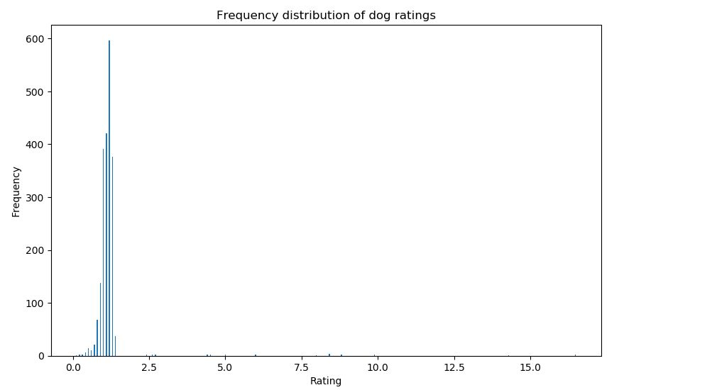

#### Rating vs Favourites

what happens when the variables are swapped?

- the converse occurs, trivially

conclusion: there appears to be no clear correlation between the variables

[figure not shown]

#### Rating vs Re-tweets

[figure not shown]

#### Popularity Contest

- `Labrador retriever` appears to be the most popular
- `retriever`-type dogs take the first 2 positions

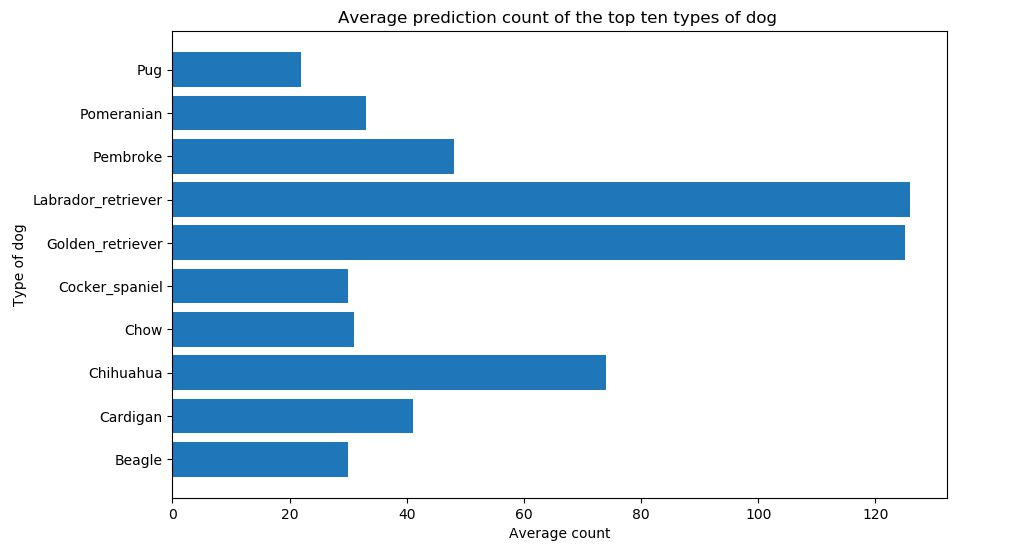

#### Correlation between the rating of a dog, its retweets and favourites

- there appears to be a strong positive correlation between
  - re-tweet count and favourite count -> *c.* 0.93
- there appears to be a weak positive correlation between
  - rating and re-tweet count -> *c.* 0.04
  - rating and favourite count -> *c.* 0.05

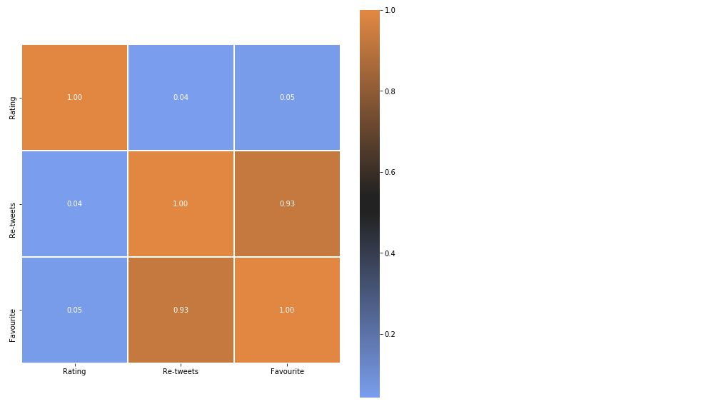

### Summary of Insights

1. average rating of a dog is c. 1.18, that is to say, 11.8 out of 10
2. majority of the ratings are close to the mean
3. there appears to be a weak positive correlation between `ratings` and `favorite_count`
4. `Labrador retriever` appears to be the most popular
5. `retriever`-type dogs take the first 2 positions
6. there appears to be a strong positive correlation between `retweet_count` and `favorite_count`
7. there appears to be a weak positive correlation between `rating` and `retweet_count`

```python
from subprocess import call
call(['python', '-m', 'nbconvert', 'act_report.html'])
```